# Лабораторная работа №14

Имитационное моделирование

Серёгина Ирина Андреевна

Российский университет дружбы народов, Москва, Россия

09 мая 2025

## Цель работы

Освоить среду моделирования gpss и реализовать несколько моделей с помощью неё.

## Задание

1. Построить модель оформления заказов клиентов одним оператором и выполнить упражнение.
2. Построить модель обслуживания двух типов заказов от клиентов в интернет-магазине и выполнить упражнение.
3. Построить модель оформления заказов несколькими операторами и выполнить упражнение.

## Модель оформления заказов клиентов одним оператором

В интернет-магазине заказы принимает один оператор. Интервалы поступления заказов распределены равномерно с интервалом 15 ± 4 мин. Время оформления заказа также распределено равномерно на интервале 10 ± 2 мин. Обработка поступивших заказов происходит в порядке очереди (FIFO). Требуется разработать модель обработки заказов в течение 8 часов.

## Модель оформления заказов клиентов одним оператором

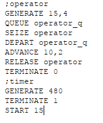

Модель оформления заказов клиентов одним оператором

## Модель оформления заказов клиентов одним оператором

[figure not shown]

Отчёт модели оформления заказов клиентов одним оператором

## Упражнение

Скорректируйте модель в соответствии с изменениями входных данных: интервалы поступления заказов распределены равномерно с интервалом 3.14 ± 1.7 мин; время оформления заказа также распределено равномерно на интервале 6.66 ± 1.7 мин. Проанализируйте отчёт, сравнив результаты с результатами предыдущего моделирования.

## Упражнение

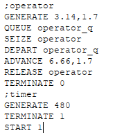

Модель оформления заказов клиентов одним оператором

## Упражнение

[figure not shown]

Отчёт модели оформления заказов клиентов одним оператором

## Построение гистограммы

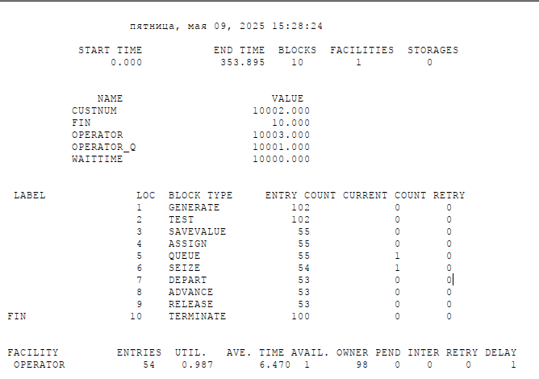

Отчёт модели оформления заказов клиентов одним оператором

## Построение гистограммы

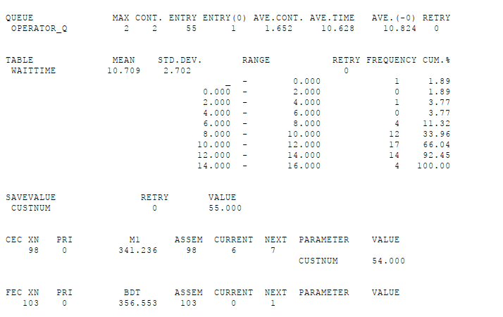

Отчёт модели оформления заказов клиентов одним оператором

## Построение гистограммы

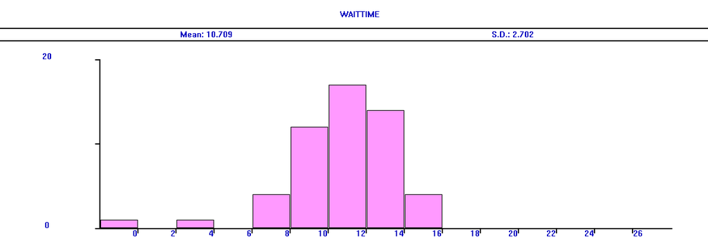

Гистограмма

## Модель обслуживания двух типов заказов от клиентов в интернет-магазине

В интернет-магазин к одному оператору поступают два типа заявок от клиентов — обычный заказ и заказ с оформление дополнительного пакета услуг. Заявки первого типа поступают каждые 15 ± 4 мин. Заявки второго типа — каждые 30 ± 8 мин. Оператор обрабатывает заявки по принципу FIFO («первым пришел — первым обслужился»). Время, затраченное на оформление обычного заказа, составляет 10 ± 2 мин, а на оформление дополнительного пакета услуг — 5 ± 2 мин. Требуется разработать модель обработки заказов в течение 8 часов, обеспечив сбор данных об очереди заявок от клиентов.

## Модель обслуживания двух типов заказов от клиентов в интернет-магазине

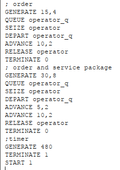

Модель обслуживания двух типов заказов от клиентов в интернет-магазине

## Модель обслуживания двух типов заказов от клиентов в интернет-магазине

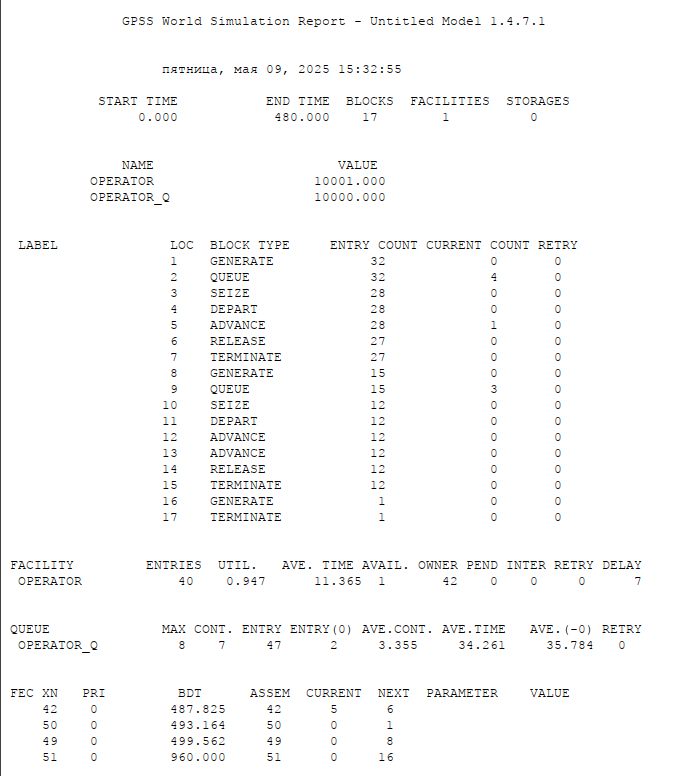

Отчёт модели обслуживания двух типов заказов от клиентов в интернет-магазине

## Упражнение

Скорректируйте модель так, чтобы учитывалось условие, что число заказов с дополнительным пакетом услуг составляет 30% от общего числа заказов. Используйте оператор TRANSFER. Проанализируйте отчёт.

## Упражнение

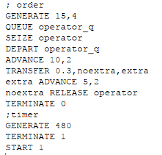

Модель обслуживания двух типов заказов от клиентов в интернет-магазине

## Упражнение

[figure not shown]

Отчёт модели обслуживания двух типов заказов от клиентов в интернет-магазине

## Модель оформления заказов несколькими операторами

В интернет-магазине заказы принимают 4 оператора. Интервалы поступления заказов распределены равномерно с интервалом 5 ± 2 мин. Время оформления заказа каждым оператором также распределено равномерно на интервале 10 ± 2 мин. Обработка поступивших заказов происходит в порядке очереди (FIFO). Требуется определить характеристики очереди заявок на оформление заказов при условии, что заявка может обрабатываться одним из 4-х операторов в течение восьмичасового рабочего дня.

## Модель оформления заказов несколькими операторами

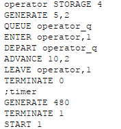

Модель оформления заказов несколькими операторами

## Модель оформления заказов несколькими операторами

[figure not shown]

Отчёт модели оформления заказов несколькими операторами

## Упражнение

Измените модель: требуется учесть в ней возможные отказы клиентов от заказа — когда при подаче заявки на заказ клиент видит в очереди более двух других заявок, он отказывается от подачи заявки, то есть отказывается от обслуживания (используйте блок TEST и стандартный числовой атрибут Qj текущей длины очереди j).

## Упражнение

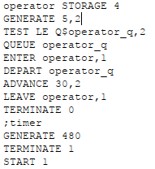

Модель оформления заказов несколькими операторами

## Упражнение

[figure not shown]

Отчёт модели оформления заказов несколькими операторами

## Выводы

Я освоила среду моделирования gpss и реализовала несколько моделей с помощью неё.

Спасибо за внимание!!